# Prediction Assignment Writeup

LHalton

February 25, 2016

## Background

Using devices such as Jawbone Up, Nike FuelBand, and Fitbit it is now possible to collect a large amount of data about personal activity relatively inexpensively. These type of devices are part of the quantified self movement - a group of enthusiasts who take measurements about themselves regularly to improve their health, to find patterns in their behavior, or because they are tech geeks. One thing that people regularly do is quantify how much of a particular activity they do, but they rarely quantify how well they do it. In this project, your goal will be to use data from accelerometers on the belt, forearm, arm, and dumbell of 6 participants. They were asked to perform barbell lifts correctly and incorrectly in 5 different ways. More information is available from the website here: http://groupware.les.inf.puc-rio.br/har (see the section on the Weight Lifting Exercise Dataset).

## Data

Data

The training data for this project are available here:

https://d396qusza40orc.cloudfront.net/predmachlearn/pml-training.csv

The test data are available here:

https://d396qusza40orc.cloudfront.net/predmachlearn/pml-testing.csv

The data for this project comes from this source: http://groupware.les.inf.puc-rio.br/har.

## Analysis

1. We will begin the analysis by downloading the data from the website http://groupware.les.inf.puc-rio.br/har.

```r
TrainingURL <- "https://d396qusza40orc.cloudfront.net/predmachlearn/pml-training.csv"

TestingURL <- "https://d396qusza40orc.cloudfront.net/predmachlearn/pml-testing.csv"

TrainingData <- read.csv(url(TrainingURL), na.strings=c("NA","DIV/0!",""))

TestingData <- read.csv(url(TestingURL), na.strings=c("NA","DIV/0!",""))
```

2. We will clean the data after loading the data set by deleting columns with missing values and deleting variables that we will not be using for analysis:

```r
TrainingData <- TrainingData [,colSums(is.na(TrainingData)) == 0]
TestingData <- TestingData [,colSums(is.na(TestingData)) == 0]

TrainingData <- TrainingData[,-c(1:7)]
TestingData <- TestingData[,-c(1:7)]
```

3. We will partition the data into 2 sets for training and testing:

```r
library(caret)
inTrain <- createDataPartition(y=TrainingData$classe, p=0.6, list=FALSE)
myTraining <- TrainingData[inTrain, ]; myTesting <- TrainingData[-inTrain, ]
dim(myTraining); dim(myTesting)
```

```
## [1] 11776    53
```

```
## [1] 7846   53
```

4. Review the “classe” variable frequency:

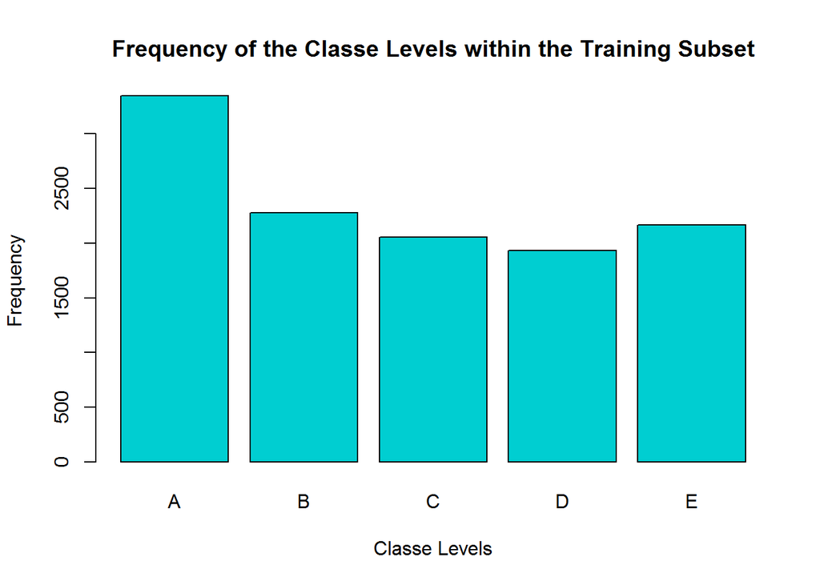

```r
plot(myTraining$classe, col="darkturquoise", main="Frequency of the Classe Levels within the Training Subset", xlab="Classe Levels", ylab="Frequency")
```

5. Correlation:

```r
Hcorr <- caret::findCorrelation(cor(myTraining[, -53]), cutoff=0.8)
names(myTraining)[Hcorr]
```

```
##  [1] "accel_belt_z"     "roll_belt"        "accel_belt_y"
##  [4] "accel_dumbbell_z" "accel_belt_x"     "pitch_belt"
##  [7] "accel_dumbbell_x" "accel_arm_x"      "magnet_arm_y"
## [10] "gyros_forearm_y"  "gyros_dumbbell_x" "gyros_dumbbell_z"
## [13] "gyros_arm_x"
```

6. Decision Tree:

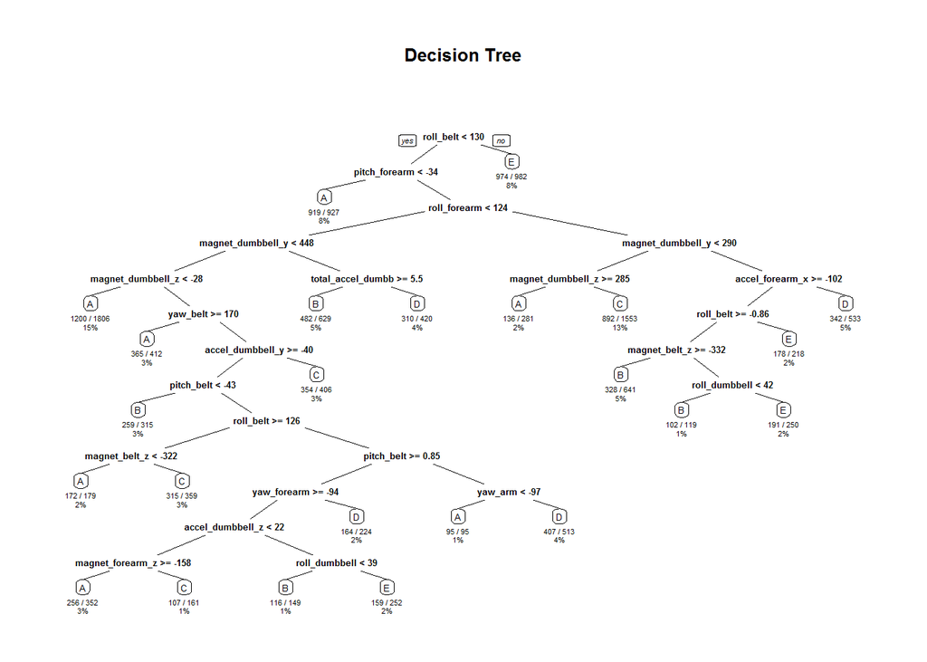

```r
library(rpart.plot)
Model1 <- rpart(classe ~ ., data=myTraining, method="class")
Prediction1 <- predict(Model1, myTesting, type = "class")
rpart.plot(Model1, main="Decision Tree", extra=102, under=TRUE, faclen=0)
```

```r
confusionMatrix(Prediction1, myTesting$classe)
```

```
## Confusion Matrix and Statistics
##
##           Reference
## Prediction    A    B    C    D    E
##          A 2064  356   36  154   73
##          B   50  833  140   44  139
##          C   56  183 1092  194  151
##          D   27  116  100  833   89
##          E   35   30    0   61  990
##
## Overall Statistics
##
##                Accuracy : 0.7408
##                  95% CI : (0.7309, 0.7504)
##     No Information Rate : 0.2845
##     P-Value [Acc > NIR] : < 2.2e-16
##
##                   Kappa : 0.6699
##  Mcnemar's Test P-Value : < 2.2e-16
##
## Statistics by Class:
##
##                      Class: A Class: B Class: C Class: D Class: E
## Sensitivity            0.9247   0.5487   0.7982   0.6477   0.6865
## Specificity            0.8897   0.9411   0.9098   0.9494   0.9803
## Pos Pred Value         0.7693   0.6907   0.6516   0.7150   0.8871
## Neg Pred Value         0.9675   0.8968   0.9553   0.9322   0.9328
## Prevalence             0.2845   0.1935   0.1744   0.1639   0.1838
## Detection Rate         0.2631   0.1062   0.1392   0.1062   0.1262
## Detection Prevalence   0.3420   0.1537   0.2136   0.1485   0.1422
## Balanced Accuracy      0.9072   0.7449   0.8540   0.7986   0.8334
```

7. Random Forest:

```r
library(randomForest)
Model2 <- randomForest(classe ~. , data=myTraining, method="class")
Prediction2 <- predict(Model2, myTesting, type = "class")
confusionMatrix(Prediction2, myTesting$classe)
```

```
## Confusion Matrix and Statistics
##
##           Reference
## Prediction    A    B    C    D    E
##          A 2230    9    0    0    0
##          B    2 1505   11    0    0
##          C    0    4 1357   20    1
##          D    0    0    0 1263    0
##          E    0    0    0    3 1441
##
## Overall Statistics
##
##                Accuracy : 0.9936
##                  95% CI : (0.9916, 0.9953)
##     No Information Rate : 0.2845
##     P-Value [Acc > NIR] : < 2.2e-16
##
##                   Kappa : 0.9919
##  Mcnemar's Test P-Value : NA
##
## Statistics by Class:
##
##                      Class: A Class: B Class: C Class: D Class: E
## Sensitivity            0.9991   0.9914   0.9920   0.9821   0.9993
## Specificity            0.9984   0.9979   0.9961   1.0000   0.9995
## Pos Pred Value         0.9960   0.9914   0.9819   1.0000   0.9979
## Neg Pred Value         0.9996   0.9979   0.9983   0.9965   0.9998
## Prevalence             0.2845   0.1935   0.1744   0.1639   0.1838
## Detection Rate         0.2842   0.1918   0.1730   0.1610   0.1837
## Detection Prevalence   0.2854   0.1935   0.1761   0.1610   0.1840
## Balanced Accuracy      0.9988   0.9947   0.9940   0.9911   0.9994
```

## Answer Submission Files

```r
pml_write_files = function(x){
  n = length(x)
  for(i in 1:n){
    filename = paste0("problem_id_",i,".txt")
    write.table(x[i],file=filename,quote=FALSE,row.names=FALSE,col.names=FALSE)
  }
}

pml_write_files(Prediction2)
```